# Predicting Condominium Sale Prices

Sofiane Ikkour

#### **Context and goal:**

In this project, we’ll build multiple linear regression models to predict condominium sale prices for all five boroughs of New York City: Bronx, Brooklyn, Manhattan, Staten Island, and Queens.

The diagram below shows the five boroughs:

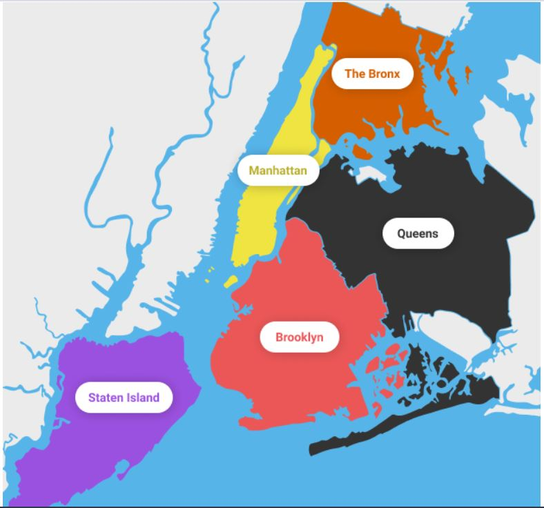

Boroughs of New York City

The purpose of our work is to find out how well the size of a condominium (measured in gross square feet) explain sale price across New York City as a whole and for each individual borough.

**Dataset:**

We’ll use condominium sales data from all five boroughs of New York City. The datasets are publicly available [here](https://www1.nyc.gov/site/finance/taxes/property-rolling-sales-data.page).

These datasets contains all sales from April 2021 to March 2022.

**Note:** This code was written on RStudio.  
**Language:** R.  
**Packages:** readr, readxl, dplyr, magrittr, stringr, tidyr, ggplot2, data.table, purrr, broom.

**Load and read the datasets**

```r
# load the relevant libraries
library(readr)
library(readxl)
library(dplyr)
library(magrittr)
library(stringr)
library(tidyr)
```

```r
library(ggplot2)
library(data.table)
library(purrr)
library(broom)

# set the working directory
setwd("C:/Users/Aylan/Documents/IT/DataQuest/R/Predicting Condominium Sale Prices")

# read file for Staten Island
staten_island <- read_excel("rollingsales_statenisland.xlsx", skip = 4)

# display the first few rows
head(staten_island)
```

```
## # A tibble: 6 x 21
##   BOROUGH NEIGHBORHOOD `BUILDING CLASS C~ `TAX CLASS AT PR~ BLOCK   LOT EASEMENT
##   <chr>   <chr>        <chr>              <chr>             <dbl> <dbl> <lgl>
## 1 5       ANNADALE     01 ONE FAMILY DWE~ 1                  5391    10 NA
## 2 5       ANNADALE     01 ONE FAMILY DWE~ 1                  5398    35 NA
## 3 5       ANNADALE     01 ONE FAMILY DWE~ 1                  5399    37 NA
## 4 5       ANNADALE     01 ONE FAMILY DWE~ 1                  5401     5 NA
## 5 5       ANNADALE     01 ONE FAMILY DWE~ 1                  5401    42 NA
## 6 5       ANNADALE     01 ONE FAMILY DWE~ 1                  5403     1 NA
## # ... with 14 more variables: BUILDING CLASS AT PRESENT <chr>, ADDRESS <chr>,
## #   APARTMENT NUMBER <chr>, ZIP CODE <dbl>, RESIDENTIAL UNITS <dbl>,
## #   COMMERCIAL UNITS <dbl>, TOTAL UNITS <dbl>, LAND SQUARE FEET <dbl>,
## #   GROSS SQUARE FEET <dbl>, YEAR BUILT <dbl>, TAX CLASS AT TIME OF SALE <chr>,
## #   BUILDING CLASS AT TIME OF SALE <chr>, SALE PRICE <dbl>, SALE DATE <dttm>
```

```r
# read file for Queens
queens <- read_excel("rollingsales_queens.xlsx", skip = 4)

# display the first few rows
head(queens)
```

```
## # A tibble: 6 x 21
##   BOROUGH NEIGHBORHOOD  `BUILDING CLASS C~ `TAX CLASS AT P~ BLOCK   LOT EASEMENT
##   <chr>   <chr>         <chr>              <chr>            <dbl> <dbl> <lgl>
## 1 4       AIRPORT LA G~ 01 ONE FAMILY DWE~ 1                  949    24 NA
## 2 4       AIRPORT LA G~ 01 ONE FAMILY DWE~ 1                  949    30 NA
## 3 4       AIRPORT LA G~ 01 ONE FAMILY DWE~ 1                  976    15 NA
## 4 4       AIRPORT LA G~ 01 ONE FAMILY DWE~ 1                  976    26 NA
## 5 4       AIRPORT LA G~ 01 ONE FAMILY DWE~ 1                  976    60 NA
## 6 4       AIRPORT LA G~ 01 ONE FAMILY DWE~ 1                  976    62 NA
## # ... with 14 more variables: BUILDING CLASS AT PRESENT <chr>, ADDRESS <chr>,
## #   APARTMENT NUMBER <chr>, ZIP CODE <dbl>, RESIDENTIAL UNITS <dbl>,
## #   COMMERCIAL UNITS <dbl>, TOTAL UNITS <dbl>, LAND SQUARE FEET <dbl>,
## #   GROSS SQUARE FEET <dbl>, YEAR BUILT <dbl>, TAX CLASS AT TIME OF SALE <chr>,
## #   BUILDING CLASS AT TIME OF SALE <chr>, SALE PRICE <dbl>, SALE DATE <dttm>
```

```r
# read file for Manhattan
manhattan <- read_excel("rollingsales_manhattan.xlsx", skip = 4)

# display the first few rows
head(manhattan)
```

```
## # A tibble: 6 x 21
##   BOROUGH NEIGHBORHOOD  `BUILDING CLASS C~ `TAX CLASS AT P~ BLOCK   LOT EASEMENT
##   <chr>   <chr>         <chr>              <chr>            <dbl> <dbl> <lgl>
## 1 1       ALPHABET CITY 02 TWO FAMILY DWE~ 1                  377    70 NA
## 2 1       ALPHABET CITY 07 RENTALS - WALK~ 2                  376    54 NA
## 3 1       ALPHABET CITY 07 RENTALS - WALK~ 2                  385    46 NA
## 4 1       ALPHABET CITY 07 RENTALS - WALK~ 2                  386    53 NA
## 5 1       ALPHABET CITY 07 RENTALS - WALK~ 2B                 389    47 NA
## 6 1       ALPHABET CITY 07 RENTALS - WALK~ 2                  390    57 NA
## # ... with 14 more variables: BUILDING CLASS AT PRESENT <chr>, ADDRESS <chr>,
## #   APARTMENT NUMBER <chr>, ZIP CODE <dbl>, RESIDENTIAL UNITS <dbl>,
## #   COMMERCIAL UNITS <dbl>, TOTAL UNITS <dbl>, LAND SQUARE FEET <dbl>,
## #   GROSS SQUARE FEET <dbl>, YEAR BUILT <dbl>, TAX CLASS AT TIME OF SALE <chr>,
## #   BUILDING CLASS AT TIME OF SALE <chr>, SALE PRICE <dbl>, SALE DATE <dttm>
```

```r
# read file for Brooklyn
brooklyn <- read_excel("rollingsales_brooklyn.xlsx", skip = 4)

# display the first few rows
head(brooklyn)
```

```
## # A tibble: 6 x 21
##   BOROUGH NEIGHBORHOOD `BUILDING CLASS C~ `TAX CLASS AT PR~ BLOCK   LOT EASEMENT
##   <chr>   <chr>        <chr>              <chr>             <dbl> <dbl> <lgl>
## 1 3       BATH BEACH   01 ONE FAMILY DWE~ 1                  6360   157 NA
## 2 3       BATH BEACH   01 ONE FAMILY DWE~ 1                  6363    22 NA
## 3 3       BATH BEACH   01 ONE FAMILY DWE~ 1                  6363    48 NA
## 4 3       BATH BEACH   01 ONE FAMILY DWE~ 1                  6364    74 NA
## 5 3       BATH BEACH   01 ONE FAMILY DWE~ 1                  6364    74 NA
## 6 3       BATH BEACH   01 ONE FAMILY DWE~ 1                  6367    24 NA
## # ... with 14 more variables: BUILDING CLASS AT PRESENT <chr>, ADDRESS <chr>,
## #   APARTMENT NUMBER <chr>, ZIP CODE <dbl>, RESIDENTIAL UNITS <dbl>,
## #   COMMERCIAL UNITS <dbl>, TOTAL UNITS <dbl>, LAND SQUARE FEET <dbl>,
## #   GROSS SQUARE FEET <dbl>, YEAR BUILT <dbl>, TAX CLASS AT TIME OF SALE <chr>,
## #   BUILDING CLASS AT TIME OF SALE <chr>, SALE PRICE <dbl>, SALE DATE <dttm>
```

```r
# read file for The Bronx
bronx <- read_excel("rollingsales_bronx.xlsx", skip = 4)

# display the first few rows
head(bronx)
```

```
## # A tibble: 6 x 21
##   BOROUGH NEIGHBORHOOD `BUILDING CLASS C~ `TAX CLASS AT PR~ BLOCK   LOT EASEMENT
##   <chr>   <chr>        <chr>              <chr>             <dbl> <dbl> <lgl>
## 1 2       BATHGATE     01 ONE FAMILY DWE~ 1                  3037   101 NA
## 2 2       BATHGATE     01 ONE FAMILY DWE~ 1                  3039    63 NA
## 3 2       BATHGATE     01 ONE FAMILY DWE~ 1                  3045    12 NA
## 4 2       BATHGATE     01 ONE FAMILY DWE~ 1                  3046    39 NA
## 5 2       BATHGATE     01 ONE FAMILY DWE~ 1                  3048    28 NA
## 6 2       BATHGATE     01 ONE FAMILY DWE~ 1                  3053   108 NA
## # ... with 14 more variables: BUILDING CLASS AT PRESENT <chr>, ADDRESS <chr>,
## #   APARTMENT NUMBER <chr>, ZIP CODE <dbl>, RESIDENTIAL UNITS <dbl>,
## #   COMMERCIAL UNITS <dbl>, TOTAL UNITS <dbl>, LAND SQUARE FEET <dbl>,
## #   GROSS SQUARE FEET <dbl>, YEAR BUILT <dbl>, TAX CLASS AT TIME OF SALE <chr>,
## #   BUILDING CLASS AT TIME OF SALE <chr>, SALE PRICE <dbl>, SALE DATE <dttm>
```

**Preparing and cleaning the data for analysis**

```r
# combine the different dataframes into one by rows
NYC_property_sales <- bind_rows(staten_island, queens, manhattan, brooklyn, bronx)

# remove the dataframes from each borough from memory
rm("bronx", "brooklyn", "manhattan", "queens", "staten_island")

# replace borough number with corresponding borough name
NYC_property_sales <- NYC_property_sales %>%
  mutate(BOROUGH = case_when(
    BOROUGH == "1" ~ "Manhattan",
    BOROUGH == "2" ~ "Bronx",
    BOROUGH == "3" ~ "Brooklyn",
    BOROUGH == "4" ~ "Queens",
    BOROUGH == "5" ~ "Staten Island",
    TRUE        ~ "Other"
  ))

# convert all column names to lower and replace all spaces with underscores
colnames(NYC_property_sales) %<>%
  str_replace_all("\\s", "_") %>%
  tolower()

# convert capitalized columns to title case
NYC_property_sales %<>%
  mutate(neighborhood = str_to_title(neighborhood)) %>%
  mutate(building_class_category = str_to_title(building_class_category)) %>%
  mutate(address = str_to_title(address))

# retain only distinct rows and delete the "easement" column
NYC_property_sales %<>%
  distinct() %>%
  select(-easement)

# apply some filtering operations
NYC_property_sales <- NYC_property_sales %>%
  # filter the sale_price column
  # the threshold is assumed to be $10,000
  filter(sale_price > 10000) %>%
  # drop observations with gross_square_feet of 0
  filter(gross_square_feet != 0) %>%
  drop_na(gross_square_feet, sale_price) %>%
  # arrange observations alphabetically by neighborhood and borough
  arrange(borough, neighborhood)

# save the dataframe to a csv file
write_csv(NYC_property_sales, "NYC_property_sales.csv")

# display the first few rows of the combined dataset
head(NYC_property_sales)
```

```
## # A tibble: 6 x 20
##   borough neighborhood building_class_category tax_class_at_present block   lot
##   <chr>   <chr>        <chr>                   <chr>                <dbl> <dbl>
## 1 Bronx   Bathgate     01 One Family Dwellings 1                     3037   101
## 2 Bronx   Bathgate     01 One Family Dwellings 1                     3039    63
## 3 Bronx   Bathgate     01 One Family Dwellings 1                     3045    12
## 4 Bronx   Bathgate     01 One Family Dwellings 1                     3053   108
## 5 Bronx   Bathgate     02 Two Family Dwellings 1                     2912   135
## 6 Bronx   Bathgate     02 Two Family Dwellings 1                     2912   146
## # ... with 14 more variables: building_class_at_present <chr>, address <chr>,
## #   apartment_number <chr>, zip_code <dbl>, residential_units <dbl>,
## #   commercial_units <dbl>, total_units <dbl>, land_square_feet <dbl>,
## #   gross_square_feet <dbl>, year_built <dbl>, tax_class_at_time_of_sale <chr>,
## #   building_class_at_time_of_sale <chr>, sale_price <dbl>, sale_date <dttm>
```

Now that we have prepared and cleaned our data which then we loaded to R, we can explore the data. However, this data is the most recent and contains a lot of missing values that makes it very hard to build predictive models with it. After conducting some research, I found out that as of July 2020, gross_square_feet is not being collected for the building class “R4” due to the ongoing Covid-19 pandemic. Therefore, I preferred to use data that contains sales from November 1, 2018 to October 31, 2019. I named the file NYC_property_sales_v2.

```r
# load the second version of the dataset into R
NYC_property_sales_v2 <- read_csv("NYC_property_sales_v2.csv")
# display the first few rows
head(NYC_property_sales_v2)
```

```
## # A tibble: 6 x 20
##   borough neighborhood building_class_category tax_class_at_present block   lot
##   <chr>   <chr>        <chr>                   <chr>                <dbl> <dbl>
## 1 Bronx   Bathgate     01 One Family Dwellings 1                     3030    62
## 2 Bronx   Bathgate     01 One Family Dwellings 1                     3030    70
## 3 Bronx   Bathgate     01 One Family Dwellings 1                     3039    63
## 4 Bronx   Bathgate     01 One Family Dwellings 1                     3043    55
## 5 Bronx   Bathgate     01 One Family Dwellings 1                     3046    35
## 6 Bronx   Bathgate     01 One Family Dwellings 1                     3046    39
## # ... with 14 more variables: building_class_at_present <chr>, address <chr>,
## #   apartment_number <chr>, zip_code <dbl>, residential_units <dbl>,
## #   commercial_units <dbl>, total_units <dbl>, land_square_feet <dbl>,
## #   gross_square_feet <dbl>, year_built <dbl>, tax_class_at_time_of_sale <dbl>,
## #   building_class_at_time_of_sale <chr>, sale_price <dbl>, sale_date <dttm>
```

**Data exploration**

In this step, we’ll generate scatterplots to visualize sale_price vs gross_square_feet for all sale records combined and for each borough individually. We then study the plots and determine if there are any outliers that require investigation.

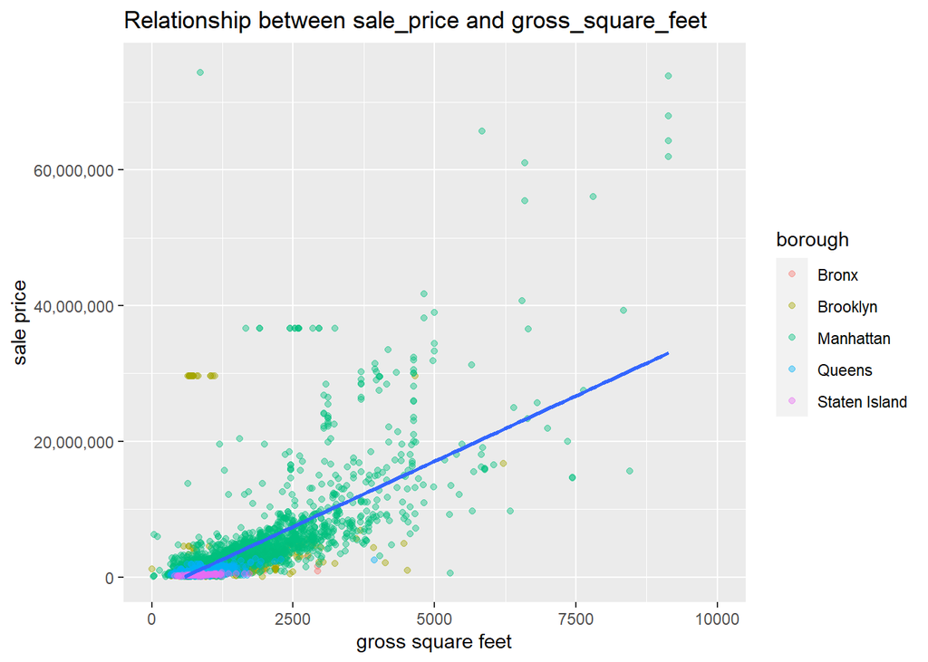

```r
# filter the NYC_property_sales to include only the building class "13 Condos - Elevator Apartments
# the variable to filter is building_class_at_time_of_sale with the code "R4"
NYC_condos <- NYC_property_sales_v2 %>%
  filter(building_class_at_time_of_sale == "R4")

# generate a scatterplot using the the NYC_condos dataframe
# with gross_square_feet on the x-axis and sale_price on the y-axis
ggplot(data = NYC_condos,
       aes(x = gross_square_feet, y = sale_price)) +
  geom_point(aes(color = borough), alpha = 0.4) +
  scale_y_continuous(labels = scales::comma, limits = c(0, 75000000)) +
  xlim(0, 10000) +
  geom_smooth(method = "lm", se = FALSE) +
  labs(
    title = "Relationship between sale_price and gross_square_feet",
    x = "gross square feet",
    y = "sale price"
  )
```

**Observations:**

- The scatterplot above shows the relationship between condominium sale prices explained by size for all boroughs of New York City combined.
- The relationship seems to follow a linear pattern, but we can also observe some spread of the data which results in a certain amount of outliers.
- The strength of the relationship is moderate.

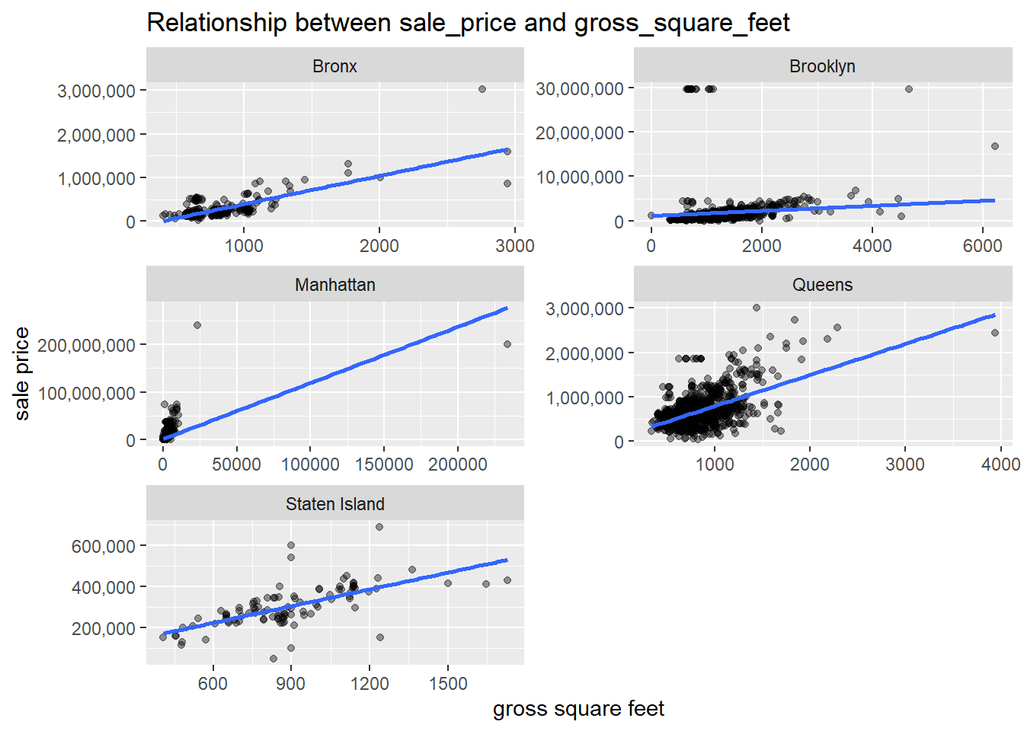

```r
# generate another scatterplot to visualize the spread of data for each borough individually
ggplot(data = NYC_condos,
       aes(x = gross_square_feet, y = sale_price)) +
  geom_point(alpha = 0.4) +
  scale_y_continuous(labels = scales::comma) +
  geom_smooth(method = "lm", se = FALSE) +
  labs(
    title = "Relationship between sale_price and gross_square_feet",
    x = "gross square feet",
    y = "sale price"
  ) +
  facet_wrap(vars(borough), ncol = 2, scales = "free")
```

**Observations:**

- The scatterplot above shows the relationship between condominium sale prices explained by size for all boroughs of New York City visualized individually. We eliminated y-axis and x-axis scales so that they can be specific to each borough.
- We can see that in general, the sale price tends to increase when the size of the condominium is higher.
- The relationship seems to follow a linear pattern except for Manhattan in which the relationship is not visually clear. This probably due to the highest price which renders the scale too high.
- The strength of the relationship seems to be moderate for most boroughs except for the Queens borough where the relationship is weaker between the sale price and the condominium size.

**Dealing with outliers**

From the previous plots, we noticed that there are some outliers worth investigating because they may represent erroneous data points which may affect the quality of our linear regression models.

Let’s begin with Manhattan. Notably, there are two points with a recorded sale price at or above $200 million. One of the reasons these sale prices are so high is the fact that some of the transactions are multiple units purchased in a single transaction. We would like to limit our analysis to transactions of single units wherever possible because this misrepresents the true cost of each unit and can impact modeling results.  
The scatterplot for Brooklyn borough shows a cluster of outliers with a recorded sale price of around $30 million. The same reason described previously for the Manhattan borough is suspected and will be investigated as well.

In this step, we’ll use some filtering methods to identify and remove from the NYC_condos dataframe multi-unit sales that misrepresent sale price.

Let’s begin by sorting all sale records by sale price from high to low.

```r
# sort sale records by sale price
NYC_condos_sorted <- NYC_condos %>%
  arrange(desc(sale_price))

# display the 20 first rows
head(NYC_condos_sorted, 20)
```

```
## # A tibble: 20 x 20
##    borough   neighborhood     building_class_cate~ tax_class_at_pre~ block   lot
##    <chr>     <chr>            <chr>                <chr>             <dbl> <dbl>
##  1 Manhattan Midtown West     13 Condos - Elevato~ 2                  1030  1082
##  2 Manhattan Upper East Side~ 13 Condos - Elevato~ 2                  1401  1003
##  3 Manhattan Gramercy         13 Condos - Elevato~ 2                   901  1001
##  4 Manhattan Upper East Side~ 13 Condos - Elevato~ 2                  1375  1441
##  5 Manhattan Upper East Side~ 13 Condos - Elevato~ 2                  1375  1438
##  6 Manhattan Midtown West     13 Condos - Elevato~ 2                  1030  1117
##  7 Manhattan Upper East Side~ 13 Condos - Elevato~ 2                  1375  1437
##  8 Manhattan Upper East Side~ 13 Condos - Elevato~ 2                  1375  1436
##  9 Manhattan Midtown West     13 Condos - Elevato~ 2                  1030  1079
## 10 Manhattan Tribeca          13 Condos - Elevato~ 2                   223  1147
## 11 Manhattan Midtown West     13 Condos - Elevato~ 2                  1030  1077
## 12 Manhattan Flatiron         13 Condos - Elevato~ 2                   827  1048
## 13 Manhattan Midtown West     13 Condos - Elevato~ 2                  1030  1086
## 14 Manhattan Tribeca          13 Condos - Elevato~ 2                   223  1146
## 15 Manhattan Tribeca          13 Condos - Elevato~ 2                   223  1144
## 16 Manhattan Midtown West     13 Condos - Elevato~ 2                  1030  1111
## 17 Manhattan Midtown West     13 Condos - Elevato~ 2                  1030  1083
## 18 Manhattan Tribeca          13 Condos - Elevato~ 2                   223  1105
## 19 Manhattan Tribeca          13 Condos - Elevato~ 2                   223  1123
## 20 Manhattan Tribeca          13 Condos - Elevato~ 2                   223  1124
## # ... with 14 more variables: building_class_at_present <chr>, address <chr>,
## #   apartment_number <chr>, zip_code <dbl>, residential_units <dbl>,
## #   commercial_units <dbl>, total_units <dbl>, land_square_feet <dbl>,
## #   gross_square_feet <dbl>, year_built <dbl>, tax_class_at_time_of_sale <dbl>,
## #   building_class_at_time_of_sale <chr>, sale_price <dbl>, sale_date <dttm>
```

```r
# make a copy of the dataframe NYC_condos
NYC_condos_original <- copy(NYC_condos)

# remove the sale record for 165 East 66th Street because it represents the sale of multiple units
NYC_condos <- NYC_condos %>%
  filter(address != "165 East 66th St, Resi")

# the most expensive home sale listed at the address "220 Central Park South, 50" is an outlier,
# but it is not an erroneous entry
# this sale record will remain in the dataframe
```

Now let’s investigate the sale record of around $30 million in the Brooklyn borough and determine if the sale_price reflects multiple units.

```r
# sort the records by sale price for the Brookyln borough
NYC_condos_brooklyn_sorted <- NYC_condos %>%
  filter(borough == "Brooklyn") %>%
  arrange(desc(sale_price))

# display the first 100 rows
head(NYC_condos_brooklyn_sorted, 100)
```

```
## # A tibble: 100 x 20
##    borough  neighborhood building_class_category  tax_class_at_pres~ block   lot
##    <chr>    <chr>        <chr>                    <chr>              <dbl> <dbl>
##  1 Brooklyn Gowanus      13 Condos - Elevator Ap~ 2                   1046  1001
##  2 Brooklyn Gowanus      13 Condos - Elevator Ap~ 2                   1046  1002
##  3 Brooklyn Gowanus      13 Condos - Elevator Ap~ 2                   1046  1003
##  4 Brooklyn Gowanus      13 Condos - Elevator Ap~ 2                   1046  1004
##  5 Brooklyn Gowanus      13 Condos - Elevator Ap~ 2                   1046  1005
##  6 Brooklyn Gowanus      13 Condos - Elevator Ap~ 2                   1046  1006
##  7 Brooklyn Gowanus      13 Condos - Elevator Ap~ 2                   1046  1007
##  8 Brooklyn Gowanus      13 Condos - Elevator Ap~ 2                   1046  1008
##  9 Brooklyn Gowanus      13 Condos - Elevator Ap~ 2                   1046  1009
## 10 Brooklyn Gowanus      13 Condos - Elevator Ap~ 2                   1046  1010
## # ... with 90 more rows, and 14 more variables:
## #   building_class_at_present <chr>, address <chr>, apartment_number <chr>,
## #   zip_code <dbl>, residential_units <dbl>, commercial_units <dbl>,
## #   total_units <dbl>, land_square_feet <dbl>, gross_square_feet <dbl>,
## #   year_built <dbl>, tax_class_at_time_of_sale <dbl>,
## #   building_class_at_time_of_sale <chr>, sale_price <dbl>, sale_date <dttm>
```

Looking through the results we see that there are approximately 40 sales records with a price of around $30 million. we also see that all 40 property sales took place on the same day, 2019-04-08. This indicates that a transaction took place on this date where all 40 units were purchased for a total price of $30 million, not $30 million per unit.  
we will remove all 40 observations from the dataset because sale prices for each unit are erroneous.

Next, we’ll build a filter that returns all sale records with three or more observations that have the same sale price and sale date.

```r
# isolate observations that have the same sale price and sale date
multi_unit_sales <- NYC_condos %>%
  group_by(sale_price, sale_date) %>%
  filter(n() >= 3) %>%
  arrange(desc(sale_price))

# display the first few rows
head(multi_unit_sales, 20)
```

```
## # A tibble: 20 x 20
## # Groups:   sale_price, sale_date [2]
##    borough   neighborhood building_class_category  tax_class_at_pre~ block   lot
##    <chr>     <chr>        <chr>                    <chr>             <dbl> <dbl>
##  1 Manhattan Tribeca      13 Condos - Elevator Ap~ 2                   223  1105
##  2 Manhattan Tribeca      13 Condos - Elevator Ap~ 2                   223  1123
##  3 Manhattan Tribeca      13 Condos - Elevator Ap~ 2                   223  1124
##  4 Manhattan Tribeca      13 Condos - Elevator Ap~ 2                   223  1125
##  5 Manhattan Tribeca      13 Condos - Elevator Ap~ 2                   223  1126
##  6 Manhattan Tribeca      13 Condos - Elevator Ap~ 2                   223  1127
##  7 Manhattan Tribeca      13 Condos - Elevator Ap~ 2                   223  1128
##  8 Manhattan Tribeca      13 Condos - Elevator Ap~ 2                   223  1129
##  9 Manhattan Tribeca      13 Condos - Elevator Ap~ 2                   223  1130
## 10 Manhattan Tribeca      13 Condos - Elevator Ap~ 2                   223  1131
## 11 Manhattan Tribeca      13 Condos - Elevator Ap~ 2                   223  1132
## 12 Manhattan Tribeca      13 Condos - Elevator Ap~ 2                   223  1134
## 13 Manhattan Tribeca      13 Condos - Elevator Ap~ 2                   223  1137
## 14 Manhattan Tribeca      13 Condos - Elevator Ap~ 2                   223  1140
## 15 Manhattan Tribeca      13 Condos - Elevator Ap~ 2                   223  1143
## 16 Brooklyn  Gowanus      13 Condos - Elevator Ap~ 2                  1046  1001
## 17 Brooklyn  Gowanus      13 Condos - Elevator Ap~ 2                  1046  1002
## 18 Brooklyn  Gowanus      13 Condos - Elevator Ap~ 2                  1046  1003
## 19 Brooklyn  Gowanus      13 Condos - Elevator Ap~ 2                  1046  1004
## 20 Brooklyn  Gowanus      13 Condos - Elevator Ap~ 2                  1046  1005
## # ... with 14 more variables: building_class_at_present <chr>, address <chr>,
## #   apartment_number <chr>, zip_code <dbl>, residential_units <dbl>,
## #   commercial_units <dbl>, total_units <dbl>, land_square_feet <dbl>,
## #   gross_square_feet <dbl>, year_built <dbl>, tax_class_at_time_of_sale <dbl>,
## #   building_class_at_time_of_sale <chr>, sale_price <dbl>, sale_date <dttm>
```

The dataframe shows that most of the sale records included in it are part of a multi-unit transaction. Let’s remove these multi-unit sales from the NYC_condos dataframe.

```r
# remove the multi-unit transactions from the NYC_condos dataframe
NYC_condos <- NYC_condos %>%
  group_by(sale_price, sale_date) %>%
  filter(n() <= 2) %>%
  ungroup
```

**Building linear regression models**

In this section, we’ll generate linear regression models before and after cleaning to determine if removing multi-unit sales impacts linear model accuracy.

```r
# generate a linear model of sale_price explained by gross_square_feet for the NYC_condos dataframe
NYC_condos_lm <- lm(sale_price ~ gross_square_feet, data = NYC_condos)

# generate a linear model of sale_price explained by gross_square_feet for the NYC_condos_original dataframe
NYC_condos_original_lm <- lm(sale_price ~ gross_square_feet, data = NYC_condos_original)

# view summary on the NYC_condos_lm model
summary(NYC_condos_lm)
```

```
##
## Call:
## lm(formula = sale_price ~ gross_square_feet, data = NYC_condos)
##
## Residuals:
##       Min        1Q    Median        3Q       Max
## -19865368   -840026    156635    938585 140321290
##
## Coefficients:
##                     Estimate Std. Error t value Pr(>|t|)
## (Intercept)       -3.110e+06  5.709e+04  -54.47   <2e-16 ***
## gross_square_feet  4.462e+03  3.947e+01  113.04   <2e-16 ***
## ---
## Signif. codes:  0 '***' 0.001 '**' 0.01 '*' 0.05 '.' 0.1 ' ' 1
##
## Residual standard error: 2945000 on 7944 degrees of freedom
## Multiple R-squared:  0.6166, Adjusted R-squared:  0.6166
## F-statistic: 1.278e+04 on 1 and 7944 DF,  p-value: < 2.2e-16
```

```r
# view summary on the NYC_condos_original_lm model
summary(NYC_condos_original_lm)
```

```
##
## Call:
## lm(formula = sale_price ~ gross_square_feet, data = NYC_condos_original)
##
## Residuals:
##       Min        1Q    Median        3Q       Max
## -79533546  -1211195   -860173   -251714 211550415
##
## Coefficients:
##                    Estimate Std. Error t value Pr(>|t|)
## (Intercept)       940683.39   57703.86   16.30   <2e-16 ***
## gross_square_feet   1192.72      19.43   61.39   <2e-16 ***
## ---
## Signif. codes:  0 '***' 0.001 '**' 0.01 '*' 0.05 '.' 0.1 ' ' 1
##
## Residual standard error: 4745000 on 8094 degrees of freedom
## Multiple R-squared:  0.3177, Adjusted R-squared:  0.3176
## F-statistic:  3769 on 1 and 8094 DF,  p-value: < 2.2e-16
```

*Analysis:*

For both cases, our hypothesis tested here can be stated as follows:  
- H0: The variable gross_square_feet does not explain or predict the sale_price variable. - Ha: The variable gross_square_feet explains or predicts the sale_price variable.

According to the results for t-statistic and p-value obtained in the summary, we can reject the null hypothesis. The threshold of the p-value being fixed at 0.05, the value we have is lower than this threshold in both models.

```r
# determine the confidence interval for slope for NYC_condos_lm
print(confint(NYC_condos_lm))
```

```
##                          2.5 %       97.5 %
## (Intercept)       -3221775.590 -2997955.090
## gross_square_feet     4384.254     4538.999
```

```r
# determine the confidence interval for slope for NYC_condos_original_lm
print(confint(NYC_condos_original_lm))
```

```
##                        2.5 %      97.5 %
## (Intercept)       827568.990 1053797.787
## gross_square_feet   1154.636    1230.802
```

The confidence interval for the NYC_condos dataset is [4384.254, 4538.999] compared to just [1154.636, 1230.802] for the NYC_condos_original dataset.

```r
# extract the RSE for the NYC_condos_lm model
print(sigma(NYC_condos_lm))
```

```
## [1] 2945202
```

```r
# extract the RSE for the NYC_condos_lm model
print(sigma(NYC_condos_original_lm))
```

```
## [1] 4744508
```

We can see that the residual standard error (RSE) for the NYC_condos dataset is 2945202 which is lower than the residual standard error (RSE) for the NYC_condos_original dataset which is 4744508.

Finaly the R-squared of the NYC_condos_lm model is 0.6166 which is significantly higher than the R-squared of the NYC_condos_original_lm which is 0.3177. This means that our data cleaning process had a positive impact on the accuracy of the prediction of our model.

Now let’s regenerate the sacatterplot visualized by borough to see how the results have changed after removing the multi-unit sales.

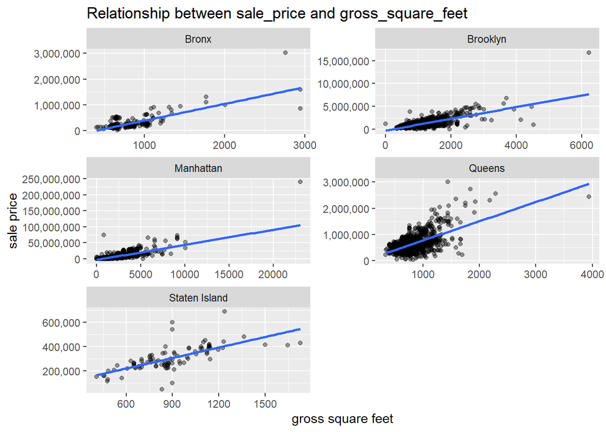

```r
# generate a scatterplot to visualize the spread of data for each borough individually
ggplot(data = NYC_condos,
       aes(x = gross_square_feet, y = sale_price)) +
  geom_point(alpha = 0.4) +
  scale_y_continuous(labels = scales::comma) +
  geom_smooth(method = "lm", se = FALSE) +
  labs(
    title = "Relationship between sale_price and gross_square_feet",
    x = "gross square feet",
    y = "sale price"
  ) +
  facet_wrap(vars(borough), ncol = 2, scales = "free")
```

For the Brooklyn borough, we can see that the line fits better the data after we removed the $30 million outliers. The same remark can be made for the Manhattan borough because we removed the $200 million multi-unit sale.

**Building linear regression models for each borough**

Now instead of comparing two models from different datasets, let’s compare linear models of sale_price predicted by gross_square_feet for each borough individually.

```r
# create a nested dataframe
NYC_nested <- NYC_condos %>%
  group_by(borough) %>%
  nest() %>%
  # fit linear models to each borough individually
  mutate(
    linear_model = map(.x = data,
                       .f = ~lm(sale_price ~ gross_square_feet,
                       data = .))) %>%
  # generate a tidy dataframe of coefficient estimates that includes confidence intervals
  mutate(
    tidy_coefficients = map(.x = linear_model,
                            .f = tidy,
                            conf.int = TRUE))

# unnest to a tidy dataframe of coefficient estimates
tidy_coefficients <- NYC_nested %>%
  select(borough, tidy_coefficients) %>%
  unnest(cols = tidy_coefficients)

# print tidy_coefficients
tidy_coefficients
```

```
## # A tibble: 10 x 8
## # Groups:   borough [5]
##    borough       term  estimate std.error statistic   p.value conf.low conf.high
##    <chr>         <chr>    <dbl>     <dbl>     <dbl>     <dbl>    <dbl>     <dbl>
##  1 Bronx         (Int~  -2.54e5   24668.     -10.3  9.89e- 22  -3.03e5  -205485.
##  2 Bronx         gros~   6.49e2      29.6     21.9  2.58e- 66   5.91e2      707.
##  3 Brooklyn      (Int~  -2.72e5   34487.      -7.88 5.64e- 15  -3.40e5  -204248.
##  4 Brooklyn      gros~   1.29e3      29.7     43.2  1.06e-275   1.23e3     1344.
##  5 Manhattan     (Int~  -3.25e6   85837.     -37.9  1.94e-275  -3.42e6 -3085712.
##  6 Manhattan     gros~   4.73e3      51.8     91.3  0           4.63e3     4829.
##  7 Queens        (Int~   3.99e4   28311.       1.41 1.59e-  1  -1.56e4    95481.
##  8 Queens        gros~   7.33e2      32.0     22.9  8.14e- 94   6.70e2      795.
##  9 Staten Island (Int~   4.64e4   28256.       1.64 1.04e-  1  -9.67e3   102536.
## 10 Staten Island gros~   2.89e2      30.7      9.41 3.30e- 15   2.28e2      349.
```

```r
# filter tidied dataframe to return slope estimate
slope <- tidy_coefficients %>%
  filter(term == "gross_square_feet") %>%
  arrange(estimate)

# print slope
slope
```

```
## # A tibble: 5 x 8
## # Groups:   borough [5]
##   borough       term   estimate std.error statistic   p.value conf.low conf.high
##   <chr>         <chr>     <dbl>     <dbl>     <dbl>     <dbl>    <dbl>     <dbl>
## 1 Staten Island gross~     289.      30.7      9.41 3.30e- 15     228.      349.
## 2 Bronx         gross~     649.      29.6     21.9  2.58e- 66     591.      707.
## 3 Queens        gross~     733.      32.0     22.9  8.14e- 94     670.      795.
## 4 Brooklyn      gross~    1285.      29.7     43.2  1.06e-275    1227.     1344.
## 5 Manhattan     gross~    4728.      51.8     91.3  0            4626.     4829.
```

We’ve arranged the results in ascending order by the slope estimate. For each of the five boroughs, the t-statistic and p-value indicate that there is a relationship between sale_price and gross_square_feet.  
In Staten Island, an increase in square footage by one unit is estimated to increase the sale price by about $288, on average.  
In Manhattan, an increase in total square footage by one unit is estimated to result in an increase in sale price of about $4,728, on average.

Finally, we will generate a tidy dataframe of regression summary statistics for each borough.

```r
# create a nested dataframe
NYC_nested_2 <- NYC_condos %>%
  group_by(borough) %>%
  nest() %>%
  # fit linear models to each borough individually
  mutate(
    linear_model = map(.x = data,
                       .f = ~lm(sale_price ~ gross_square_feet, data = .))
  ) %>%
  # generate a tidy dataframe of regression summary statistics for each borough
  mutate(
    tidy_summary_stats = map(.x = linear_model, .f = glance)
  )

# print NYC_nested_2
NYC_nested_2
```

```
## # A tibble: 5 x 4
## # Groups:   borough [5]
##   borough       data                  linear_model tidy_summary_stats
##   <chr>         <list>                <list>       <list>
## 1 Bronx         <tibble [330 x 19]>   <lm>         <tibble [1 x 12]>
## 2 Brooklyn      <tibble [1,697 x 19]> <lm>         <tibble [1 x 12]>
## 3 Manhattan     <tibble [4,819 x 19]> <lm>         <tibble [1 x 12]>
## 4 Queens        <tibble [1,004 x 19]> <lm>         <tibble [1 x 12]>
## 5 Staten Island <tibble [96 x 19]>    <lm>         <tibble [1 x 12]>
```

```r
# unnest to a single tidy dataframe that includes regression summary statistics
summary_stats <- NYC_nested_2 %>%
  select(borough, tidy_summary_stats) %>%
  unnest(cols = tidy_summary_stats)

# print summary_stats
summary_stats
```

```
## # A tibble: 5 x 13
## # Groups:   borough [5]
##   borough       r.squared adj.r.squared  sigma statistic   p.value    df  logLik
##   <chr>             <dbl>         <dbl>  <dbl>     <dbl>     <dbl> <dbl>   <dbl>
## 1 Bronx             0.595         0.594 1.51e5     481.  2.58e- 66     1  -4404.
## 2 Brooklyn          0.524         0.524 5.65e5    1868.  1.06e-275     1 -24883.
## 3 Manhattan         0.634         0.634 3.59e6    8337.  0             1 -79570.
## 4 Queens            0.344         0.343 2.80e5     525.  8.14e- 94     1 -14018.
## 5 Staten Island     0.485         0.480 7.35e4      88.6 3.30e- 15     1  -1211.
## # ... with 5 more variables: AIC <dbl>, BIC <dbl>, deviance <dbl>,
## #   df.residual <int>, nobs <int>
```

**Observations:**

Regression summary statistics indicate that gross_square_feet is a better single predictor of sale_price in some boroughs versus others.  
For example, the R-squared value was estimated at approximately 0.63 in Manhattan, and 0.59 in Bronx compared to an estimate of only 0.35 in Queens. These differences in R-squared correspond with the scatterplots generated for each borough; the strength of sale prices versus gross square feet was higher, and the dispersion (spread) was lower for Manhattan and Brooklyn as compared to Queens where the relationship was noticeably weaker because the data was more spread out.